# MinIon raw reads query with megablast against nt

## QC and conversion

```
for s in {1..5}
do
    filtlong --min_mean_q 20 --mean_q_weight 10 ../sampleData/sample$s/sample$s-combined.fastq > filtlong_q20/sample$s-q20.fastq
    seqkit fq2fa  filtlong_q20/sample$s-q20.fastq > fastas_q20/sample$s-q20.fasta
done
```

```python
!filtlong --version
```

```
Filtlong v0.2.1
```

## BLASTn against nt

We can do the filtering later

```
for s in {1..5}
do
    blastn -query fastas_q20/sample$s-q20.fasta \
        -db /storage/AUX_1T_SSD/blastDBs/nt \
        -outfmt '6 qaccver saccver pident length mismatch gapopen qstart qend sstart send evalue bitscore staxid ssciname stitle' \
        -num_threads 16 -max_target_seqs 50 \
        -out blast_results/sample$s-q20.blst
done
mv blast_results blast_results_done  # to avoid timely re-execution
```

```python
!blastn -version
```

```
blastn: 2.14.0+
 Package: blast 2.14.0, build Apr  5 2023 12:25:48
```

## Import the samples into a dataframe

```python
import pandas as pd
import numpy as np

from subprocess import call

import matplotlib.pyplot as plt
import seaborn as sns
import plotly.express as px

import plotly.io as pio
pio.renderers.default = "plotly_mimetype+notebook"
```

```python
pio.templates.default = "plotly_white"
```

```python
! ls -lh blast_results_done/
```

```
total 1.1G
-rw-rw-r-- 1 armand armand 148M Nov 22 15:59 sample1-q20.blst
-rw-rw-r-- 1 armand armand 329M Nov 22 21:57 sample2-q20.blst
-rw-rw-r-- 1 armand armand 129M Nov 23 00:41 sample3-q20.blst
-rw-rw-r-- 1 armand armand 250M Nov 23 05:52 sample4-q20.blst
-rw-rw-r-- 1 armand armand 234M Nov 23 10:35 sample5-q20.blst
```

```python
blastDf = pd.DataFrame()
names = 'qaccver saccver pident length mismatch gapopen qstart qend sstart send evalue bitscore staxid ssciname stitle'.split(" ")
for s in range(1,6):
    f = f'blast_results_done/sample{s}-q20.blst'
    tmp = pd.read_csv(f, sep="\t", names=names)
    tmp['sample'] = s
    blastDf = pd.concat([blastDf, tmp])
```

```python
blastDf['sample'].value_counts()
```

```
sample
2    1425013
4    1167139
5     985877
1     585234
3     546011
Name: count, dtype: int64
```

The above value counts also correlates with the file sizes for the blast results, just a sanity check

When we did the blast results we returned 50 hits per query, next we can sort the results and keep only one hit per query

Also we did blast against nt, we can use taxonkit to get the taxonomy lineage and filter for fungi

## Filter the results

```python
len(blastDf['staxid'].unique())
```

```
24726
```

```python
blastDf['staxid'].unique().tofile('taxids.txt', sep='\n', format='%s')
```

### Taxonkit

```python
!taxonkit
```

```
TaxonKit - A Practical and Efficient NCBI Taxonomy Toolkit

Version: 0.15.0

Author: Wei Shen <shenwei356@gmail.com>

Source code: https://github.com/shenwei356/taxonkit
Documents  : https://bioinf.shenwei.me/taxonkit
Citation   : https://www.sciencedirect.com/science/article/pii/S1673852721000837

Dataset:

    Please download and uncompress "taxdump.tar.gz":
    ftp://ftp.ncbi.nih.gov/pub/taxonomy/taxdump.tar.gz

    and copy "names.dmp", "nodes.dmp", "delnodes.dmp" and "merged.dmp" to data directory:
    "/home/armand/.taxonkit"

    or some other directory, and later you can refer to using flag --data-dir,
    or environment variable TAXONKIT_DB.

    When environment variable TAXONKIT_DB is set, explicitly setting --data-dir will
    overide the value of TAXONKIT_DB.

Usage:
  taxonkit [command]

Available Commands:
  cami-filter     Remove taxa of given TaxIds and their descendants in CAMI metagenomic profile
  create-taxdump  Create NCBI-style taxdump files for custom taxonomy, e.g., GTDB and ICTV
  filter          Filter TaxIds by taxonomic rank range
  genautocomplete generate shell autocompletion script (bash|zsh|fish|powershell)
  lca             Compute lowest common ancestor (LCA) for TaxIds
  lineage         Query taxonomic lineage of given TaxIds
  list            List taxonomic subtrees of given TaxIds
  name2taxid      Convert scientific names to TaxIds
  profile2cami    Convert metagenomic profile table to CAMI format
  reformat        Reformat lineage in canonical ranks
  taxid-changelog Create TaxId changelog from dump archives
  version         print version information and check for update

Flags:
      --data-dir string   directory containing nodes.dmp and names.dmp (default "/home/armand/.taxonkit")
  -h, --help              help for taxonkit
      --line-buffered     use line buffering on output, i.e., immediately writing to stdin/file for
                          every line of output
  -o, --out-file string   out file ("-" for stdout, suffix .gz for gzipped out) (default "-")
  -j, --threads int       number of CPUs. 4 is enough (default 4)
      --verbose           print verbose information

Use "taxonkit [command] --help" for more information about a command.
```

```python
!taxonkit lineage --help
```

```
Query taxonomic lineage of given TaxIds

Input:

  - List of TaxIds, one TaxId per line.
  - Or tab-delimited format, please specify TaxId field
    with flag -i/--taxid-field (default 1).
  - Supporting (gzipped) file or STDIN.

Output:

  1. Input line data.
  2. (Optional) Status code (-c/--show-status-code), values:
     - "-1" for queries not found in whole database.
     - "0" for deleted TaxIds, provided by "delnodes.dmp".
     - New TaxIds for merged TaxIds, provided by "merged.dmp".
     - Taxids for these found in "nodes.dmp".
  3. Lineage, delimiter can be changed with flag -d/--delimiter.
  4. (Optional) TaxIds taxons in the lineage (-t/--show-lineage-taxids)
  5. (Optional) Name (-n/--show-name)
  6. (Optional) Rank (-r/--show-rank)

Filter out invalid and deleted taxids, and replace merged
taxids with new ones:

    # input is one-column-taxid
    $ taxonkit lineage -c taxids.txt \
        | awk '$2>0' \
        | cut -f 2-

    # taxids are in 3rd field in a 4-columns tab-delimited file,
    # for $5, where 5 = 4 + 1.
    $ cat input.txt \
        | taxonkit lineage -c -i 3 \
        | csvtk filter2 -H -t -f '$5>0' \
        | csvtk -H -t cut -f -3

Usage:
  taxonkit lineage [flags]

Flags:
  -d, --delimiter string      field delimiter in lineage (default ";")
  -h, --help                  help for lineage
  -L, --no-lineage            do not show lineage, when user just want names or/and ranks
  -R, --show-lineage-ranks    appending ranks of all levels
  -t, --show-lineage-taxids   appending lineage consisting of taxids
  -n, --show-name             appending scientific name
  -r, --show-rank             appending rank of taxids
  -c, --show-status-code      show status code before lineage
  -i, --taxid-field int       field index of taxid. input data should be tab-separated (default 1)

Global Flags:
      --data-dir string   directory containing nodes.dmp and names.dmp (default "/home/armand/.taxonkit")
      --line-buffered     use line buffering on output, i.e., immediately writing to stdin/file for
                          every line of output
  -o, --out-file string   out file ("-" for stdout, suffix .gz for gzipped out) (default "-")
  -j, --threads int       number of CPUs. 4 is enough (default 4)
      --verbose           print verbose information
```

```python
%%capture
%%bash
cat taxids.txt \
    | taxonkit reformat -I 1 -f "{k}|{K}|{p}|{c}|{o}|{f}|{g}|{s}" \
    | csvtk pretty -H -t \
    | grep Fungi \
    | sed 's/  */|/g' \
    | cut -d"|" -f 1,2,3,4,5,6,7,8,9,10 \
    > lineage.csv
```

```python
!cat lineage.csv |wc -l
```

```
14468
```

```python
!head lineage.csv
```

```
101201|Eukaryota|Fungi|Ascomycota|Sordariomycetes|Hypocreales|Hypocreaceae|Trichoderma|Trichoderma|asperellum
29875|Eukaryota|Fungi|Ascomycota|Sordariomycetes|Hypocreales|Hypocreaceae|Trichoderma|Trichoderma|virens
1381934|Eukaryota|Fungi|Basidiomycota|Malasseziomycetes|Malasseziales|Malasseziaceae|Malassezia|Malassezia|caprae
1715236|Eukaryota|Fungi|Mucoromycota|Mucoromycetes|Mucorales|Mucoraceae|Mucor|Mucor|sp.
40559|Eukaryota|Fungi|Ascomycota|Leotiomycetes|Helotiales|Sclerotiniaceae|Botrytis|Botrytis|cinerea
182845|Eukaryota|Fungi|Ascomycota|Sordariomycetes|Hypocreales|Nectriaceae|Calonectria|Calonectria|ilicicola
1331945|Eukaryota|Fungi|Ascomycota|Sordariomycetes|Hypocreales|Hypocreaceae|Trichoderma|Trichoderma|virens
498019|Eukaryota|Fungi|Ascomycota|Saccharomycetes|Saccharomycetales|Metschnikowiaceae|Candida/Metschnikowiaceae|[Candida]|auris
175245|Eukaryota|Fungi||||||uncultured|fungus
179640|Eukaryota|Fungi||||||uncultured|zygomycete
```

```python
ranks = 'staxid, Domain, Kingdom, Phylum, Division, Class, Order, Family, Genus, Species'.split(", ")
linDf = pd.read_csv("lineage.csv", sep="|", names=ranks)
linDf
```

|  | staxid | Domain | Kingdom | Phylum | Division | Class | Order | Family | Genus | Species |
| --- | --- | --- | --- | --- | --- | --- | --- | --- | --- | --- |
| 0 | 101201 | Eukaryota | Fungi | Ascomycota | Sordariomycetes | Hypocreales | Hypocreaceae | Trichoderma | Trichoderma | asperellum |
| 1 | 29875 | Eukaryota | Fungi | Ascomycota | Sordariomycetes | Hypocreales | Hypocreaceae | Trichoderma | Trichoderma | virens |
| 2 | 1381934 | Eukaryota | Fungi | Basidiomycota | Malasseziomycetes | Malasseziales | Malasseziaceae | Malassezia | Malassezia | caprae |
| 3 | 1715236 | Eukaryota | Fungi | Mucoromycota | Mucoromycetes | Mucorales | Mucoraceae | Mucor | Mucor | sp. |
| 4 | 40559 | Eukaryota | Fungi | Ascomycota | Leotiomycetes | Helotiales | Sclerotiniaceae | Botrytis | Botrytis | cinerea |
| ... | ... | ... | ... | ... | ... | ... | ... | ... | ... | ... |
| 14463 | 164786 | Eukaryota | Fungi | Basidiomycota | Agaricomycetes | Cantharellales | Ceratobasidiaceae | Rhizoctonia | Rhizoctonia | sp. |
| 14464 | 65487 | Eukaryota | Fungi | Ascomycota | Eurotiomycetes | Onygenales | Arthrodermataceae | Nannizzia | Nannizzia | persicolor |
| 14465 | 1683809 | Eukaryota | Fungi | Ascomycota | Sordariomycetes | Glomerellales | Plectosphaerellaceae | Plectosphaerella | Plectosphaerella | oratosquillae |
| 14466 | 40695 | Eukaryota | Fungi | Ascomycota | Sordariomycetes | Hypocreales | Hypocreaceae | Trichoderma | Trichoderma | polysporum |
| 14467 | 288737 | Eukaryota | Fungi | Basidiomycota | Agaricomycetes | Gomphales | Gomphaceae | Beenakia | Beenakia | fricta |

14468 rows × 10 columns

## Assign lineage to the blast results

Now that we have the lineage for all the taxonomic IDs we can assign this to the blast results

```python
df = pd.merge(blastDf, linDf, on='staxid', how='left')
df.shape
```

```
(4709274, 25)
```

```python
blastDf.shape
```

```
(4709274, 16)
```

```python
df = df .dropna(subset=ranks)
```

```python
df.shape
```

```
(1495582, 25)
```

We only assigned lineages for Fungi taxonomic ids, by merging 'left' we keep the non fungal data as a sanity check, then we drop all the resulting NaN/non-fungal data

We still have duplicated hits for our sequences, we can filter for the best hit score

We also need to do sanity checks and filter out short and low id results

```python
df.columns
```

```
Index(['qaccver', 'saccver', 'pident', 'length', 'mismatch', 'gapopen',
       'qstart', 'qend', 'sstart', 'send', 'evalue', 'bitscore', 'staxid',
       'ssciname', 'stitle', 'sample', 'Domain', 'Kingdom', 'Phylum',
       'Division', 'Class', 'Order', 'Family', 'Genus', 'Species'],
      dtype='object')
```

## Filter duplicates

```python
cleanDf = (df
             [['sample', 'qaccver', 'saccver', 'pident', 'length', 'mismatch', 'gapopen', 'evalue', 'bitscore', 'staxid',
             'Domain', 'Kingdom', 'Phylum', 'Division', 'Class', 'Order', 'Family', 'Genus', 'Species']
             ]
             .sort_values(by=['sample', 'bitscore'], ascending=[True, False]) # sort samples from low to high, and bitscore from high to low
             .drop_duplicates(subset=['sample', 'qaccver'], keep='first')
            )
```

### Look at blast scores for further filtering

```python
cleanDf['evalue'].describe()
```

```
count     3.099200e+04
mean      4.774006e-04
std       2.740719e-02
min       0.000000e+00
25%       0.000000e+00
50%      2.885000e-180
75%       4.020000e-31
max       4.500000e+00
Name: evalue, dtype: float64
```

```python
cleanDf['length'].describe()
```

```
count    30992.000000
mean       396.221477
std        240.291002
min         28.000000
25%        121.000000
50%        410.000000
75%        610.000000
max       1222.000000
Name: length, dtype: float64
```

```python
cleanDf['length'].mean()
```

```
396.22147651006713
```

#### Start with the evalue

```python
e = cleanDf['evalue'].mean()
cleanDf = cleanDf.query('evalue <= @e')
```

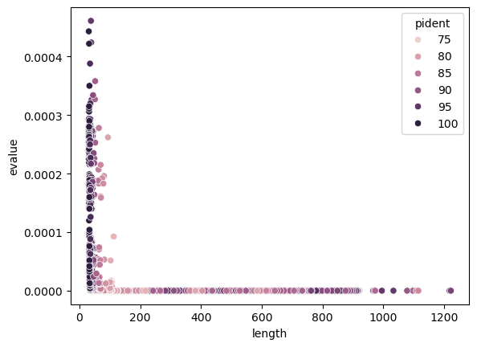

```python
sns.scatterplot(data=cleanDf, x='length', y='evalue', hue='pident')
plt.show()
```

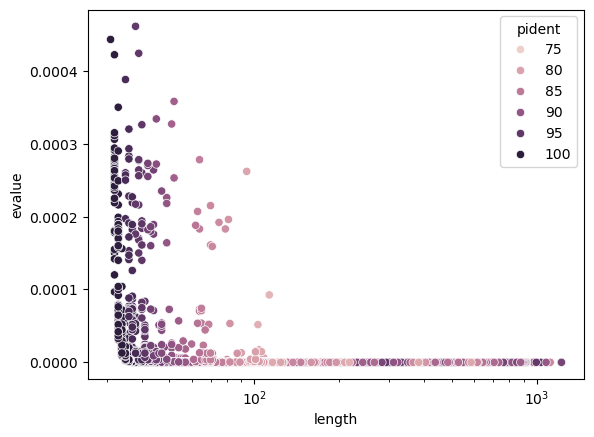

```python
sns.scatterplot(data=cleanDf, x='length', y='evalue', hue='pident')
plt.xscale("log")
plt.show()
```

```python
cleanDf.shape
```

```
(30562, 19)
```

```python
cleanDf['length'].describe()
```

```
count    30562.000000
mean       401.321805
std        238.067555
min         31.000000
25%        123.000000
50%        413.000000
75%        613.000000
max       1222.000000
Name: length, dtype: float64
```

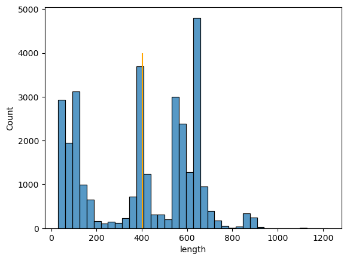

```python
sns.histplot(cleanDf['length'])
plt.vlines(x=cleanDf['length'].mean(), ymin=0, ymax=4000, color='orange')
```

```python
l = cleanDf['length'].mean()
cleanDf = cleanDf.query("length >= @l")
cleanDf.shape
```

```
(16854, 19)
```

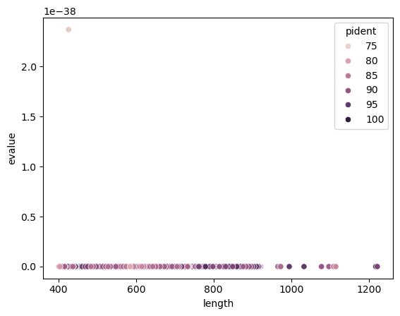

```python
sns.scatterplot(data=cleanDf, x='length', y='evalue', hue='pident')
plt.show()
```

We have now filtered our data based on e-value and length. That should likely take care of most other issues as well

```python
cleanDf
```

|  | sample | qaccver | saccver | pident | length | mismatch | gapopen | evalue | bitscore | staxid | Domain | Kingdom | Phylum | Division | Class | Order | Family | Genus | Species |
| --- | --- | --- | --- | --- | --- | --- | --- | --- | --- | --- | --- | --- | --- | --- | --- | --- | --- | --- | --- |
| 380051 | 1 | 36e899b7-f697-449b-a956-a1d223fedc22 | CP125425.1 | 93.836 | 876 | 21 | 24 | 0.000000e+00 | 1288.0 | 4932 | Eukaryota | Fungi | Ascomycota | Saccharomycetes | Saccharomycetales | Saccharomycetaceae | Saccharomyces | Saccharomyces | cerevisiae |
| 329666 | 1 | 64af7734-07a0-4d73-8aaa-aec63a5da2af | OR518419.1 | 95.969 | 769 | 19 | 10 | 0.000000e+00 | 1238.0 | 1184793 | Eukaryota | Fungi | Basidiomycota | Agaricomycetes | Agaricales | Lycoperdaceae | Lycoperdon | Lycoperdon | rupicola |
| 259298 | 1 | 91234894-b3ee-4fba-b478-59e0450ce3f6 | MH809978.1 | 99.392 | 658 | 1 | 3 | 0.000000e+00 | 1190.0 | 104412 | Eukaryota | Fungi | Basidiomycota | Tremellomycetes | Filobasidiales | Filobasidiaceae | Naganishia | Naganishia | globosa |
| 502802 | 1 | fe7af9d3-1c19-46b9-ab60-5519938b5cfa | MG938354.1 | 100.000 | 644 | 0 | 0 | 0.000000e+00 | 1190.0 | 89926 | Eukaryota | Fungi | Basidiomycota | Tremellomycetes | Cystofilobasidiales | Cystofilobasidiaceae | Cystofilobasidium | Cystofilobasidium | macerans |
| 551033 | 1 | 27fdfe2d-8553-44f1-9b2e-aa3bbfc12565 | OU989363.1 | 99.391 | 657 | 2 | 2 | 0.000000e+00 | 1190.0 | 104410 | Eukaryota | Fungi | Basidiomycota | Tremellomycetes | Filobasidiales | Filobasidiaceae | Filobasidium | Filobasidium | oeirense |
| ... | ... | ... | ... | ... | ... | ... | ... | ... | ... | ... | ... | ... | ... | ... | ... | ... | ... | ... | ... |
| 3820159 | 5 | 9dbcb5b6-955b-483d-be7f-5dfdb89c731d | EF643580.1 | 89.552 | 402 | 10 | 20 | 8.990000e-131 | 481.0 | 43976 | Eukaryota | Fungi | Ascomycota | Saccharomycetes | Saccharomycetales | Dipodascaceae | Dipodascus | Dipodascus | australiensis |
| 4045769 | 5 | 510d4fab-7d09-4325-bab3-8b1132059a73 | MN340288.1 | 86.157 | 484 | 14 | 25 | 1.510000e-128 | 473.0 | 5535 | Eukaryota | Fungi | Basidiomycota | Microbotryomycetes | Sporidiobolales | Sporidiobolaceae | Rhodotorula | Rhodotorula | glutinis |
| 4420128 | 5 | bd7f6d19-0b2e-48d0-8f18-5dc0d21d7016 | FM212569.1 | 87.414 | 437 | 11 | 19 | 3.680000e-125 | 462.0 | 564303 | Eukaryota | Fungi | Basidiomycota | Tremellomycetes | Trichosporonales | Trichosporonaceae | Trichosporon | Trichosporon | sp. |
| 4363937 | 5 | b05c215b-8f89-4ec9-b0bd-3302fe557052 | MZ380149.1 | 79.487 | 585 | 77 | 33 | 2.260000e-98 | 375.0 | 2040969 | Eukaryota | Fungi | Ascomycota | Dothideomycetes | Pleosporales | Sporormiaceae | Sporormia | Sporormia | sp. |
| 3874630 | 5 | 7a493df7-bbd0-4c03-a85e-ceaf07cd1b8d | MH859222.1 | 81.436 | 404 | 37 | 24 | 5.250000e-75 | 296.0 | 64522 | Eukaryota | Fungi | Mucoromycota | Mortierellomycetes | Mortierellales | Mortierellaceae | Linnemannia | Linnemannia | gamsii |

16854 rows × 19 columns

### Lets also get the fasta files for clean df

```python
for s in range(1, 6):
    cleanDf.query("sample == @s")['qaccver'].to_csv(f'share/sample{s}_cleanDf_header.csv', index=False, header=None)
```

Manual for seqkit

```python
!seqkit
```

```
SeqKit -- a cross-platform and ultrafast toolkit for FASTA/Q file manipulation

Version: 2.6.1

Author: Wei Shen <shenwei356@gmail.com>

Documents  : http://bioinf.shenwei.me/seqkit
Source code: https://github.com/shenwei356/seqkit
Seqkit utlizies the pgzip (https://github.com/klauspost/pgzip) package to
read and write gzip file, and the outputted gzip file would be slighty
larger than files generated by GNU gzip.

Seqkit writes gzip files very fast, much faster than the multi-threaded pigz,
therefore there's no need to pipe the result to gzip/pigz.

Seqkit also supports reading and writing xz (.xz) and zstd (.zst) formats since v2.2.0.
Bzip2 format is supported since v2.4.0.

Compression level:
  format   range   default  comment
  gzip     1-9     5        https://github.com/klauspost/pgzip sets 5 as the default value.
  xz       NA      NA       https://github.com/ulikunitz/xz does not support.
  zstd     1-4     2        roughly equals to zstd 1, 3, 7, 11, respectively.
  bzip     1-9     6        https://github.com/dsnet/compress

Usage:
  seqkit [command]

Available Commands:
  amplicon        extract amplicon (or specific region around it) via primer(s)
  bam             monitoring and online histograms of BAM record features
  common          find common/shared sequences of multiple files by id/name/sequence
  concat          concatenate sequences with the same ID from multiple files
  convert         convert FASTQ quality encoding between Sanger, Solexa and Illumina
  duplicate       duplicate sequences N times
  fa2fq           retrieve corresponding FASTQ records by a FASTA file
  faidx           create FASTA index file and extract subsequence
  fish            look for short sequences in larger sequences using local alignment
  fq2fa           convert FASTQ to FASTA
  fx2tab          convert FASTA/Q to tabular format (and length, GC content, average quality...)
```

[output cut: 36 more lines]

```
  -h, --help                            help for seqkit
      --id-ncbi                         FASTA head is NCBI-style, e.g. >gi|110645304|ref|NC_002516.2|
                                        Pseud...
      --id-regexp string                regular expression for parsing ID (default "^(\\S+)\\s?")
  -X, --infile-list string              file of input files list (one file per line), if given, they are
                                        appended to files from cli arguments
  -w, --line-width int                  line width when outputting FASTA format (0 for no wrap) (default 60)
  -o, --out-file string                 out file ("-" for stdout, suffix .gz for gzipped out) (default "-")
      --quiet                           be quiet and do not show extra information
  -t, --seq-type string                 sequence type (dna|rna|protein|unlimit|auto) (for auto, it
                                        automatically detect by the first sequence) (default "auto")
  -j, --threads int                     number of CPUs. can also set with environment variable
                                        SEQKIT_THREADS) (default 4)

Use "seqkit [command] --help" for more information about a command.
```

```python
%%bash
for s in {1..5}
do
    echo $s
    seqkit grep -nr -w 0 -f share/sample$s\_cleanDf_header.csv fastas_q20/sample$s-q20.fasta -o share/sample$s\_cleanDf.fasta
done
```

```
1
```

```
[INFO] 2340 patterns loaded from file
```

```
2
```

```
[INFO] 6257 patterns loaded from file
```

```
3
```

```
[INFO] 2857 patterns loaded from file
```

```
4
```

```
[INFO] 3043 patterns loaded from file
```

```
5
```

```
[INFO] 2357 patterns loaded from file
```

### And while we are at it also retrieve the random samples from the cleanDf and re-blast that sequence from the extracted clean fastas

sanity

```python
np.random.seed(7)
for s in range(1,6):
    print(f'\n----> Getting a sample for sample', s, "\n")

    sample = cleanDf.query("sample == @s").sample(n=1)
    print("**********\n", sample, "\n**********\n")

    qaccver = list(sample.values)[0][2]
    seqid = list(sample.values)[0][1]
    print("Accession:",qaccver)
    print('Sequence id:\n', seqid)

    grepCmd = f"grep -w -A 1 {seqid} share/sample{s}_cleanDf.fasta"
    #print(grepCmd)
    call(grepCmd, shell=True)

    print("\n\n||oxoxoxoxoxoxoxoxoxoxoxoxoxoxoxoxoxoxoxoxoxoxoxoxoxoxoxoxoxoxoxoxoxoxoxoxoxoxoxoxoxoxoxoxoxoxoxoxoxoxoxoxoxoxoxoxoxoxoxoxoxoxoxoxoxoxoxoxoxox||\n\n")
```

```
----> Getting a sample for sample 1

**********
         sample                               qaccver     saccver  pident  \
193100       1  29feb549-a100-4ea6-a76e-835af8fc8456  LN997749.1  89.649

        length  mismatch  gapopen         evalue  bitscore   staxid  \
193100     541         8       30  4.170000e-180     645.0  1774974

           Domain Kingdom         Phylum         Division        Class  \
193100  Eukaryota   Fungi  Basidiomycota  Tremellomycetes  Tremellales

                  Order        Family         Genus Species
193100  Cryptococcaceae  Cryptococcus  Cryptococcus     sp.
**********

Accession: LN997749.1
Sequence id:
 29feb549-a100-4ea6-a76e-835af8fc8456
>29feb549-a100-4ea6-a76e-835af8fc8456 runid=0229276d21dfef62cf25fefca03c06ec341ce33d read=17995 ch=28 start_time=2022-09-28T13:00:00.658861+02:00 flow_cell_id=FAR34653 protocol_group_id=27_09_22_continue sample_id=lib1 barcode=barcode16 barcode_alias=barcode16 parent_read_id=29feb549-a100-4ea6-a76e-…
TTGTACTTCGTTCAGTTACGTACGCTAAGGTTAACGTCAACTGACAGTGGTTCGTACTCA…


||oxoxoxoxoxoxoxoxoxoxoxoxoxoxoxoxoxoxoxoxoxoxoxoxoxoxoxoxoxoxoxoxoxoxoxoxoxoxoxoxoxoxoxoxoxoxoxoxoxoxoxoxoxoxoxoxoxoxoxoxoxoxoxoxoxoxoxoxoxox||



----> Getting a sample for sample 2

**********
          sample                               qaccver     saccver  pident  \
1261857       2  f4ec1211-cfed-4621-a1b3-81c0f6426383  MF084288.1  96.209

         length  mismatch  gapopen  evalue  bitscore  staxid     Domain  \
1261857     554        10        9     0.0     896.0   82518  Eukaryota

        Kingdom         Phylum         Division             Class  \
1261857   Fungi  Basidiomycota  Tremellomycetes  Trichosporonales

                     Order               Family                Genus  \
```

[output cut: 80 more lines]

```
        Kingdom         Phylum         Division        Class            Order  \
4642181   Fungi  Basidiomycota  Tremellomycetes  Tremellales  Cryptococcaceae

               Family         Genus Species
4642181  Cryptococcus  Cryptococcus     sp.
**********

Accession: AY749434.1
Sequence id:
 adb53eae-814c-4477-8c4b-f42115b731a8
>adb53eae-814c-4477-8c4b-f42115b731a8 runid=6ff1a24d2e67a1f0ad28fccf92eb1936dfec39f2 sampleid=lib1 read=10140 ch=465 start_time=2022-09-27T15:45:29Z model_version_id=2021-05-17_dna_r9.4.1_minion_768_2f1c8637 barcode=barcode24
TCCTCCGCTTATTGATATGCTTAAGTTCAGCGGGTAATCCTACCTGATTTGAGGCCACAC…


||oxoxoxoxoxoxoxoxoxoxoxoxoxoxoxoxoxoxoxoxoxoxoxoxoxoxoxoxoxoxoxoxoxoxoxoxoxoxoxoxoxoxoxoxoxoxoxoxoxoxoxoxoxoxoxoxoxoxoxoxoxoxoxoxoxoxoxoxoxox||
```

The above sanity check, checks out. There are instance where the to NCBI blast does not get the top results, use control find.

## Reporting

```python
cleanDf.to_excel('share/cleanDf.xlsx', index=None)
```

#### Explore the Phylum abundances

```python
pd.DataFrame(cleanDf.groupby(['sample'])['Phylum'].value_counts())
```

| sample | Phylum | count |
| --- | --- | --- |
| 1 | Basidiomycota | 1728 |
|  | Ascomycota | 582 |
|  | Mucoromycota | 26 |
|  | Chytridiomycota | 3 |
|  | Sanchytriomycota | 1 |
| 2 | Ascomycota | 3462 |
|  | Basidiomycota | 2635 |
|  | Mucoromycota | 158 |
|  | Zoopagomycota | 1 |
|  | Chytridiomycota | 1 |
| 3 | Ascomycota | 1581 |
|  | Basidiomycota | 1120 |
|  | Mucoromycota | 156 |
| 4 | Basidiomycota | 2120 |
|  | Ascomycota | 682 |
|  | Blastocladiomycota | 189 |
|  | Mucoromycota | 52 |
| 5 | Basidiomycota | 1306 |
|  | Ascomycota | 797 |
|  | Mucoromycota | 254 |

```python
for s in range(1, 6):
    summaryDf = pd.DataFrame(cleanDf.query('sample == @s')["Phylum"].value_counts())
    summaryDf['Percent'] = summaryDf['count'] / summaryDf['count'].sum() *100
    print('\nFor sample:', s)
    print(summaryDf)
```

```
For sample: 1
                  count    Percent
Phylum
Basidiomycota      1728  73.846154
Ascomycota          582  24.871795
Mucoromycota         26   1.111111
Chytridiomycota       3   0.128205
Sanchytriomycota      1   0.042735

For sample: 2
                 count    Percent
Phylum
Ascomycota        3462  55.330030
Basidiomycota     2635  42.112834
Mucoromycota       158   2.525172
Zoopagomycota        1   0.015982
Chytridiomycota      1   0.015982

For sample: 3
               count    Percent
Phylum
Ascomycota      1581  55.337767
Basidiomycota   1120  39.201960
Mucoromycota     156   5.460273

For sample: 4
                    count    Percent
Phylum
Basidiomycota        2120  69.668091
Ascomycota            682  22.412093
Blastocladiomycota    189   6.210976
Mucoromycota           52   1.708840

For sample: 5
               count    Percent
Phylum
Basidiomycota   1306  55.409419
Ascomycota       797  33.814171
Mucoromycota     254  10.776411
```

```python
cleanDf.columns
```

```
Index(['sample', 'qaccver', 'saccver', 'pident', 'length', 'mismatch',
       'gapopen', 'evalue', 'bitscore', 'staxid', 'Domain', 'Kingdom',
       'Phylum', 'Division', 'Class', 'Order', 'Family', 'Genus', 'Species'],
      dtype='object')
```

```python
phylumDf = pd.DataFrame(cleanDf.groupby(['sample'])[['Phylum']].value_counts()).reset_index()
phylumDf['sample'] = phylumDf['sample'].astype("str")
```

```python
fig = px.scatter(data_frame=phylumDf, x='sample', y='Phylum', size = 'count', size_max=40, height=600, width=800, color='Phylum')
fig
```

[interactive chart not shown]

[square brackets](https://support.nlm.nih.gov/knowledgebase/article/KA-03379/en-us)

```
The NCBI Taxonomy staff places square brackets around the genus for some species (for example [Candida] auris) to indicate that they are misclassified*, meaning placed incorrectly in a higher taxonomic rank. The term misclassified refers to systematics which is one of three broad areas within the science of taxonomy:

nomenclature — the naming of organisms (biological taxa)
taxonomy sensu stricto (taxonomy in the narrow sense) — the description of named taxa
systematics — the arrangement of named and described taxa in a scientifically meaningful hierarchy
In the [Candida] auris example, researchers currently established that this species does not belong to the genus Candida. The species is now awaiting to be formally renamed through the appropriate Code of Nomenclature, but until then the incorrect genus is indicated by the square brackets. Using square brackets for misclassified species has been used in bacteriology. The NCBI Taxonomy has recently expanded this convention to other organisms, such as Fungi (yeasts).

See also how the convention of using square brackets affects the file naming convention on the FTP site.

*Note: You should not confuse the term with misidentified that indicates that a specific organism has been incorrectly identified as belonging to a particular taxon that is in and of itself legitimately classified. A researcher might isolate a bacterium from soil and identify it as belonging to the species Bacillus subtilis when in fact it is a strain of Bacillus cereus. Both the names Bacillus subtilis and Bacillus cereus are properly classified as two different species of the genus Bacillus, but this particular isolate has been misidentified.
```

```python
cleanDf.query('sample == @s & Phylum == "Ascomycota"')
```

|  | sample | qaccver | saccver | pident | length | mismatch | gapopen | evalue | bitscore | staxid | Domain | Kingdom | Phylum | Division | Class | Order | Family | Genus | Species |
| --- | --- | --- | --- | --- | --- | --- | --- | --- | --- | --- | --- | --- | --- | --- | --- | --- | --- | --- | --- |
| 4368155 | 5 | a7bf4aef-c84b-4965-a1e9-fd3903e5bce5 | MZ541972.1 | 94.774 | 995 | 22 | 23 | 0.000000e+00 | 1522.0 | 2011794 | Eukaryota | Fungi | Ascomycota | Dothideomycetes | Pleosporales | Thyridariaceae | Neoroussoella | Neoroussoella | sp. |
| 4522754 | 5 | daf310ec-391e-4f9d-ab09-16e4d242eb11 | MT044448.1 | 97.162 | 881 | 9 | 11 | 0.000000e+00 | 1474.0 | 48147 | Eukaryota | Fungi | Ascomycota | Taphrinomycetes | Taphrinales | Protomycetaceae | Protomyces | Protomyces | macrosporus |
| 4324093 | 5 | c3947449-56b9-49c6-8162-5e114344a110 | CP129579.1 | 96.942 | 883 | 15 | 6 | 0.000000e+00 | 1471.0 | 4932 | Eukaryota | Fungi | Ascomycota | Saccharomycetes | Saccharomycetales | Saccharomycetaceae | Saccharomyces | Saccharomyces | cerevisiae |
| 4211691 | 5 | 0d3f6782-669f-4734-ab3b-b9da3774dbd3 | CP006426.1 | 96.145 | 882 | 10 | 16 | 0.000000e+00 | 1419.0 | 1294380 | Eukaryota | Fungi | Ascomycota | Saccharomycetes | Saccharomycetales | Saccharomycetaceae | Saccharomyces | Saccharomyces | cerevisiae |
| 4341788 | 5 | b707caf2-06d5-43a1-9b25-deb7f98d7d54 | CP006426.1 | 95.781 | 877 | 10 | 22 | 0.000000e+00 | 1389.0 | 1294380 | Eukaryota | Fungi | Ascomycota | Saccharomycetes | Saccharomycetales | Saccharomycetaceae | Saccharomyces | Saccharomyces | cerevisiae |
| ... | ... | ... | ... | ... | ... | ... | ... | ... | ... | ... | ... | ... | ... | ... | ... | ... | ... | ... | ... |
| 4449847 | 5 | be356a75-d2f6-42aa-9b34-f0e990c53bf4 | FR870476.1 | 89.078 | 412 | 25 | 16 | 1.070000e-134 | 494.0 | 4959 | Eukaryota | Fungi | Ascomycota | Saccharomycetes | Saccharomycetales | Debaryomycetaceae | Debaryomyces | Debaryomyces | hansenii |
| 4257748 | 5 | c24b3d6d-6864-4556-8490-3129d7661a45 | FR870476.1 | 88.942 | 416 | 18 | 16 | 7.660000e-133 | 488.0 | 4959 | Eukaryota | Fungi | Ascomycota | Saccharomycetes | Saccharomycetales | Debaryomycetaceae | Debaryomyces | Debaryomyces | hansenii |
| 4414125 | 5 | 8dc554fd-65d5-425b-b878-29adda10782c | CP060377.1 | 87.991 | 433 | 22 | 20 | 6.660000e-132 | 484.0 | 498019 | Eukaryota | Fungi | Ascomycota | Saccharomycetes | Saccharomycetales | Metschnikowiaceae | Candida/Metschnikowiaceae | [Candida] | auris |
| 3820159 | 5 | 9dbcb5b6-955b-483d-be7f-5dfdb89c731d | EF643580.1 | 89.552 | 402 | 10 | 20 | 8.990000e-131 | 481.0 | 43976 | Eukaryota | Fungi | Ascomycota | Saccharomycetes | Saccharomycetales | Dipodascaceae | Dipodascus | Dipodascus | australiensis |
| 4363937 | 5 | b05c215b-8f89-4ec9-b0bd-3302fe557052 | MZ380149.1 | 79.487 | 585 | 77 | 33 | 2.260000e-98 | 375.0 | 2040969 | Eukaryota | Fungi | Ascomycota | Dothideomycetes | Pleosporales | Sporormiaceae | Sporormia | Sporormia | sp. |

797 rows × 19 columns

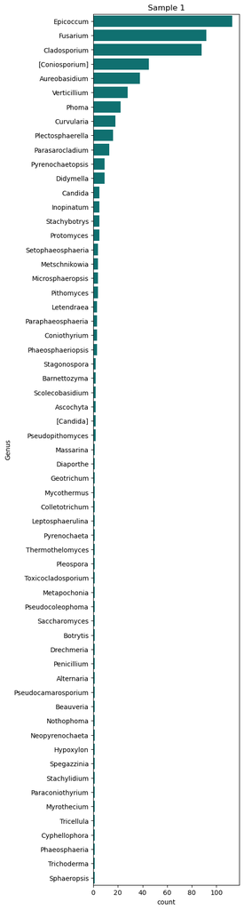

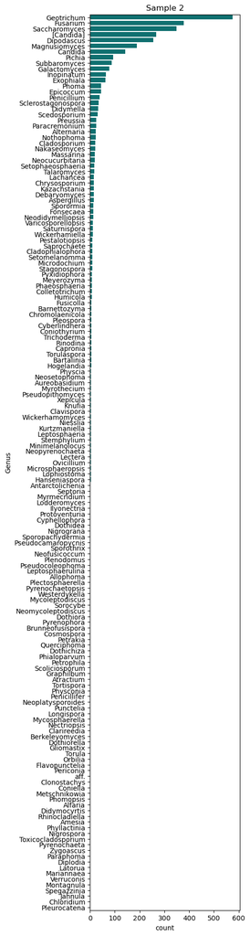

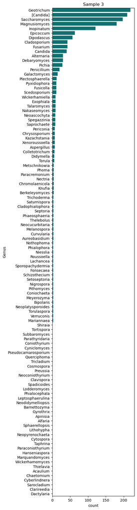

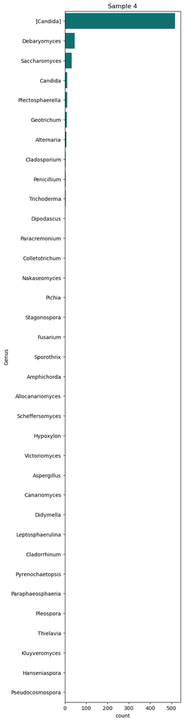

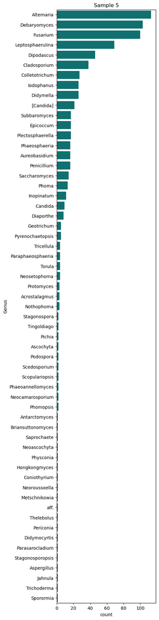

```python
for s in range(1,6):
    plt.figure(figsize=(4,24))
    sns.countplot(
        data=cleanDf.query('sample == @s & Phylum == "Ascomycota"'),
        y='Genus',
        order = cleanDf.query('sample == @s & Phylum == "Ascomycota"')['Genus'].value_counts().index,
        color='teal'
    )
    plt.title(f'Sample {s}')
    plt.show()
```

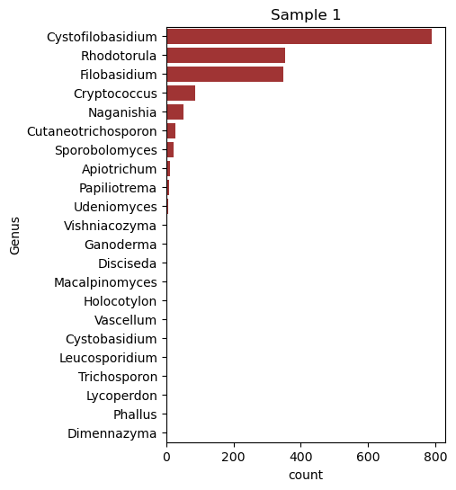

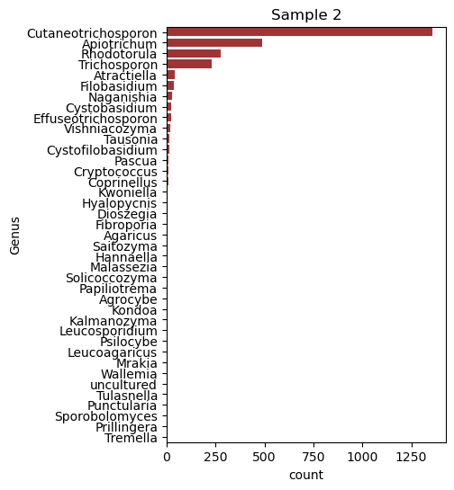

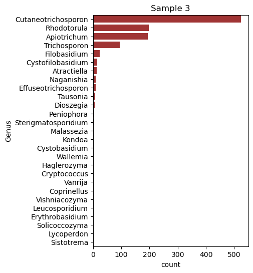

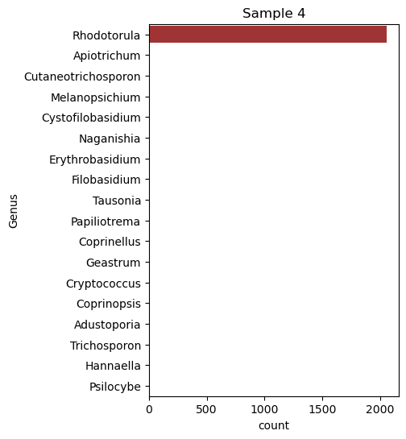

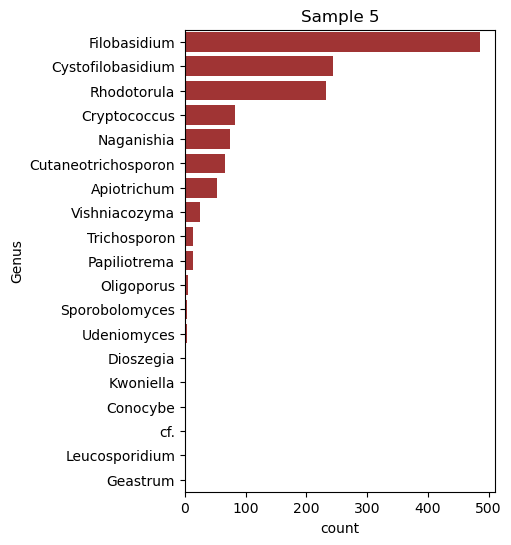

```python
for s in range(1,6):
    plt.figure(figsize=(4,6))
    sns.countplot(
        data=cleanDf.query('sample == @s & Phylum == "Basidiomycota"'),
        y='Genus',
        order = cleanDf.query('sample == @s & Phylum == "Basidiomycota"')['Genus'].value_counts().index,
        color='firebrick'
    )
    plt.title(f'Sample {s}')
    plt.show()
```

```python
above = 1

genusAscoDf = pd.DataFrame(cleanDf.query('Phylum == "Ascomycota"').groupby(['sample'])[['Genus']].value_counts()).reset_index()
genusAscoDf['sample'] = genusAscoDf['sample'].astype("str")


fig = px.scatter(data_frame=genusAscoDf.query("count > @above"),
                 x='sample', y='Genus',
                 size = 'count',
                 size_max=30, height=1200, width=800, color='Genus',
                title=f"Genus blast restuls for more than {above} hits, Ascomycota")
fig.update_xaxes(categoryorder='array', categoryarray= ['1','2','3','4', '5'])
fig.update_traces(marker=dict(line=dict(width=2, color='DarkSlateGrey')), selector=dict(mode='markers'), marker_sizemin=2)

fig
```

[interactive chart not shown]

```python
genusBasidDf = pd.DataFrame(cleanDf.query('Phylum == "Basidiomycota"').groupby(['sample'])[['Genus']].value_counts()).reset_index()
genusBasidDf['sample'] = genusBasidDf['sample'].astype("str")


fig = px.scatter(data_frame=genusBasidDf.query("count > @above"),
                 x='sample', y='Genus',
                 size = 'count',
                 size_max=30, height=1200, width=800, color='Genus',
                title=f"Genus blast restuls for more than {above} hits, Basidiomycota")
fig.update_xaxes(categoryorder='array', categoryarray= ['1','2','3','4', '5'])
fig.update_traces(marker=dict(line=dict(width=2, color='DarkSlateGrey')), selector=dict(mode='markers'), marker_sizemin=2)
fig
```

[interactive chart not shown]

```python
cleanDf['Genus_species'] = cleanDf['Genus'] + "_" + cleanDf['Species']
cleanDf['Genus_species']
```

```
380051       Saccharomyces_cerevisiae
329666            Lycoperdon_rupicola
259298             Naganishia_globosa
502802     Cystofilobasidium_macerans
551033          Filobasidium_oeirense
                      ...
3820159      Dipodascus_australiensis
4045769          Rhodotorula_glutinis
4420128              Trichosporon_sp.
4363937                 Sporormia_sp.
3874630            Linnemannia_gamsii
Name: Genus_species, Length: 16854, dtype: object
```

```python
pd.DataFrame(cleanDf.groupby(['sample', 'Phylum', 'Genus'])['Genus_species'].value_counts()).reset_index().sort_values(by=['sample', 'Phylum', 'count'],
                                                                                                             ascending=[True, True, False]).to_excel('Sample_genus_species-value_counts.xlsx', index=False)
```

```python
above = 1

speciesAscoDf = pd.DataFrame(cleanDf.query('Phylum == "Ascomycota"').groupby(['sample'])[['Genus', 'Genus_species']].value_counts()).reset_index()
speciesAscoDf['sample'] = speciesAscoDf['sample'].astype("str")


fig = px.scatter(data_frame=speciesAscoDf.query("count > @above"),
                 x='sample', y='Genus_species',
                 size = 'count',
                 size_max=30, height=2000, width=1000, color='Genus',
                title=f"Species blast restuls for more than {above} hits, Ascomycota")
fig.update_xaxes(categoryorder='array', categoryarray= ['1','2','3','4', '5'])
fig.update_traces(marker=dict(line=dict(width=2, color='DarkSlateGrey')), selector=dict(mode='markers'), marker_sizemin=2)

fig
```

[interactive chart not shown]

```python
speciesBasidDf = pd.DataFrame(cleanDf.query('Phylum == "Basidiomycota"').groupby(['sample'])[['Genus', 'Genus_species']].value_counts()).reset_index()
speciesBasidDf['sample'] = speciesBasidDf['sample'].astype("str")


fig = px.scatter(data_frame=speciesBasidDf.query("count > @above"),
                 x='sample', y='Genus_species',
                 size = 'count',
                 size_max=30, height=1200, width=1000, color='Genus',
                title=f"Species blast restuls for more than {above} hits, Basidiomycota")
fig.update_xaxes(categoryorder='array', categoryarray= ['1','2','3','4', '5'])
fig.update_traces(marker=dict(line=dict(width=2, color='DarkSlateGrey')), selector=dict(mode='markers'), marker_sizemin=2)
fig
```

[interactive chart not shown]

## Diversity

```python
def rarefaction(sample, step): # work in progress
    tmp = cleanDf.query("sample == @sample")
    sampling = np.arange(0, tmp.shape[0], step)
    rareData = pd.DataFrame(columns=['sampleSize', 'nUniqueGenus'])
    x = []
    y = []
    for n in sampling:
        x.append(n)
        y.append(len(tmp.sample(n)['Genus'].unique()))

    rareData['sampleSize'] = x
    rareData['nUniqueGenus'] = y
    rareData['sample'] = f'sample-{sample}'
    return rareData
```

```python
rarefactionDf = pd.DataFrame()
for i in range(1,6):
    tmp = rarefaction(sample=i, step=10)
    rarefactionDf = pd.concat([rarefactionDf, tmp])
```

```python
rarefactionDf
```

|  | sampleSize | nUniqueGenus | sample |
| --- | --- | --- | --- |
| 0 | 0 | 0 | sample-1 |
| 1 | 10 | 6 | sample-1 |
| 2 | 20 | 10 | sample-1 |
| 3 | 30 | 14 | sample-1 |
| 4 | 40 | 14 | sample-1 |
| ... | ... | ... | ... |
| 231 | 2310 | 80 | sample-5 |
| 232 | 2320 | 82 | sample-5 |
| 233 | 2330 | 82 | sample-5 |
| 234 | 2340 | 81 | sample-5 |
| 235 | 2350 | 82 | sample-5 |

1687 rows × 3 columns

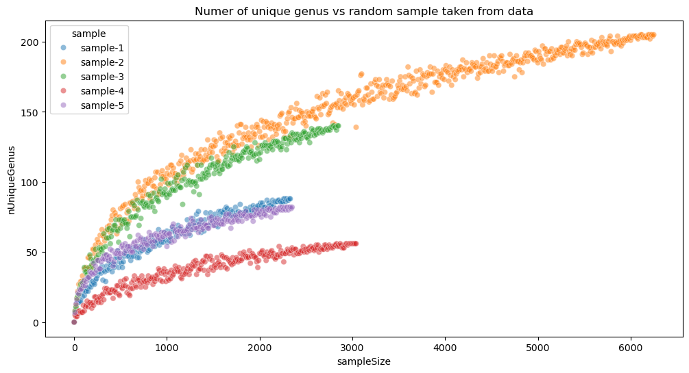

```python
plt.figure(figsize=(12,6))
sns.scatterplot(data=rarefactionDf, x='sampleSize', y='nUniqueGenus', hue='sample', alpha=0.5)
plt.title('Numer of unique genus vs random sample taken from data');
```

```python
speciesAscoDf
```

|  | sample | Genus | Genus_species | count |
| --- | --- | --- | --- | --- |
| 0 | 1 | Epicoccum | Epicoccum_nigrum | 68 |
| 1 | 1 | [Coniosporium] | [Coniosporium]_sp. | 45 |
| 2 | 1 | Fusarium | Fusarium_equiseti | 34 |
| 3 | 1 | Aureobasidium | Aureobasidium_pullulans | 33 |
| 4 | 1 | Fusarium | Fusarium_chlamydosporum | 31 |
| ... | ... | ... | ... | ... |
| 809 | 5 | Briansuttonomyces | Briansuttonomyces_sp. | 1 |
| 810 | 5 | Aureobasidium | Aureobasidium_sp. | 1 |
| 811 | 5 | Aspergillus | Aspergillus_sp. | 1 |
| 812 | 5 | Antarctomyces | Antarctomyces_psychrotrophicus | 1 |
| 813 | 5 | aff. | aff._Alternaria | 1 |

814 rows × 4 columns

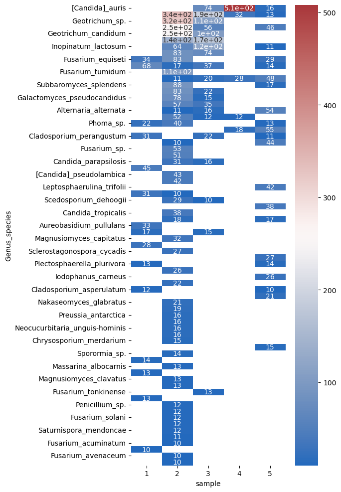

```python
count_df_Asco = pd.pivot(speciesAscoDf.drop('Genus', axis=1).query("count >= 10"), columns='sample', index="Genus_species", values='count')
count_df_Asco['sum'] = count_df_Asco.sum(axis=1, numeric_only=True)
count_df_Asco.sort_values(by='sum', ascending=False, inplace=True)
#count_df_Asco.fillna(0, inplace=True)

plt.figure(figsize=(5, 12))
sns.heatmap(count_df_Asco.drop("sum", axis=1), cmap=sns.color_palette("vlag", as_cmap=True), annot=True);
```

```python
count_df_Asco
```

| sample Genus_species | 1 | 2 | 3 | 4 | 5 | sum |
| --- | --- | --- | --- | --- | --- | --- |
| [Candida]_auris | NaN | NaN | 74.0 | 508.0 | 16.0 | 598.0 |
| Saccharomyces_cerevisiae | NaN | 339.0 | 191.0 | 32.0 | 13.0 | 575.0 |
| Geotrichum_sp. | NaN | 325.0 | 114.0 | NaN | NaN | 439.0 |
| Dipodascus_australiensis | NaN | 254.0 | 56.0 | NaN | 46.0 | 356.0 |
| Geotrichum_candidum | NaN | 251.0 | 105.0 | NaN | NaN | 356.0 |
| ... | ... | ... | ... | ... | ... | ... |
| Neodidymelliopsis_sp. | NaN | 11.0 | NaN | NaN | NaN | 11.0 |
| Fusarium_acuminatum | NaN | 10.0 | NaN | NaN | NaN | 10.0 |
| Epicoccum_sp. | 10.0 | NaN | NaN | NaN | NaN | 10.0 |
| Fusarium_avenaceum | NaN | 10.0 | NaN | NaN | NaN | 10.0 |
| Setophaeosphaeria_badalingensis | NaN | 10.0 | NaN | NaN | NaN | 10.0 |

72 rows × 6 columns

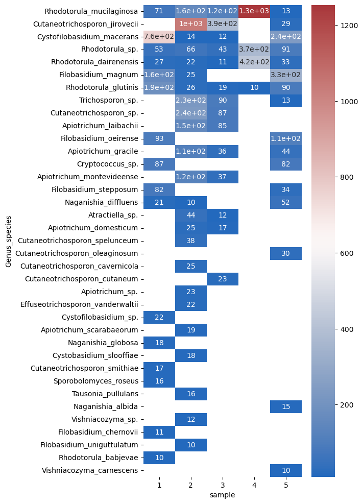

```python
count_df_Basidi = pd.pivot(speciesBasidDf.drop('Genus', axis=1).query("count >= 10"), columns='sample', index="Genus_species", values='count')
count_df_Basidi['sum'] = count_df_Basidi.sum(axis=1, numeric_only=True)
count_df_Basidi.sort_values(by='sum', ascending=False, inplace=True)
#count_df_Asco.fillna(0, inplace=True)

plt.figure(figsize=(5, 12))
sns.heatmap(count_df_Basidi.drop("sum", axis=1), cmap=sns.color_palette("vlag", as_cmap=True), annot=True);
```

```python
count_df_Basidi
```

| sample Genus_species | 1 | 2 | 3 | 4 | 5 | sum |
| --- | --- | --- | --- | --- | --- | --- |
| Rhodotorula_mucilaginosa | 71.0 | 162.0 | 120.0 | 1253.0 | 13.0 | 1619.0 |
| Cutaneotrichosporon_jirovecii | NaN | 1036.0 | 386.0 | NaN | 29.0 | 1451.0 |
| Cystofilobasidium_macerans | 758.0 | 14.0 | 12.0 | NaN | 243.0 | 1027.0 |
| Rhodotorula_sp. | 53.0 | 66.0 | 43.0 | 370.0 | 91.0 | 623.0 |
| Rhodotorula_dairenensis | 27.0 | 22.0 | 11.0 | 424.0 | 33.0 | 517.0 |
| Filobasidium_magnum | 157.0 | 25.0 | NaN | NaN | 326.0 | 508.0 |
| Rhodotorula_glutinis | 188.0 | 26.0 | 19.0 | 10.0 | 90.0 | 333.0 |
| Trichosporon_sp. | NaN | 228.0 | 90.0 | NaN | 13.0 | 331.0 |
| Cutaneotrichosporon_sp. | NaN | 238.0 | 87.0 | NaN | NaN | 325.0 |
| Apiotrichum_laibachii | NaN | 154.0 | 85.0 | NaN | NaN | 239.0 |
| Filobasidium_oeirense | 93.0 | NaN | NaN | NaN | 110.0 | 203.0 |
| Apiotrichum_gracile | NaN | 114.0 | 36.0 | NaN | 44.0 | 194.0 |
| Cryptococcus_sp. | 87.0 | NaN | NaN | NaN | 82.0 | 169.0 |
| Apiotrichum_montevideense | NaN | 123.0 | 37.0 | NaN | NaN | 160.0 |
| Filobasidium_stepposum | 82.0 | NaN | NaN | NaN | 34.0 | 116.0 |
| Naganishia_diffluens | 21.0 | 10.0 | NaN | NaN | 52.0 | 83.0 |
| Atractiella_sp. | NaN | 44.0 | 12.0 | NaN | NaN | 56.0 |
| Apiotrichum_domesticum | NaN | 25.0 | 17.0 | NaN | NaN | 42.0 |
| Cutaneotrichosporon_spelunceum | NaN | 38.0 | NaN | NaN | NaN | 38.0 |
| Cutaneotrichosporon_oleaginosum | NaN | NaN | NaN | NaN | 30.0 | 30.0 |
| Cutaneotrichosporon_cavernicola | NaN | 25.0 | NaN | NaN | NaN | 25.0 |
| Cutaneotrichosporon_cutaneum | NaN | NaN | 23.0 | NaN | NaN | 23.0 |
| Apiotrichum_sp. | NaN | 23.0 | NaN | NaN | NaN | 23.0 |
| Effuseotrichosporon_vanderwaltii | NaN | 22.0 | NaN | NaN | NaN | 22.0 |
| Cystofilobasidium_sp. | 22.0 | NaN | NaN | NaN | NaN | 22.0 |
| Apiotrichum_scarabaeorum | NaN | 19.0 | NaN | NaN | NaN | 19.0 |
| Naganishia_globosa | 18.0 | NaN | NaN | NaN | NaN | 18.0 |
| Cystobasidium_slooffiae | NaN | 18.0 | NaN | NaN | NaN | 18.0 |
| Cutaneotrichosporon_smithiae | 17.0 | NaN | NaN | NaN | NaN | 17.0 |
| Sporobolomyces_roseus | 16.0 | NaN | NaN | NaN | NaN | 16.0 |
| Tausonia_pullulans | NaN | 16.0 | NaN | NaN | NaN | 16.0 |
| Naganishia_albida | NaN | NaN | NaN | NaN | 15.0 | 15.0 |
| Vishniacozyma_sp. | NaN | 12.0 | NaN | NaN | NaN | 12.0 |
| Filobasidium_chernovii | 11.0 | NaN | NaN | NaN | NaN | 11.0 |
| Filobasidium_uniguttulatum | NaN | 10.0 | NaN | NaN | NaN | 10.0 |
| Rhodotorula_babjevae | 10.0 | NaN | NaN | NaN | NaN | 10.0 |
| Vishniacozyma_carnescens | NaN | NaN | NaN | NaN | 10.0 | 10.0 |